# Coursera Practical Machine Learning - Course Project

Aline Meret Mähr

3/24/2020

## Background

Using devices such as Jawbone Up, Nike FuelBand, and Fitbit it is now possible to collect a large amount of data about personal activity relatively inexpensively. These type of devices are part of the quantified self movement – a group of enthusiasts who take measurements about themselves regularly to improve their health, to find patterns in their behavior, or because they are tech geeks. One thing that people regularly do is quantify how much of a particular activity they do, but they rarely quantify how well they do it.

In this project, the goal is to use data from accelerometers on the belt, forearm, arm, and dumbell of 6 participants. They were asked to perform barbell lifts correctly and incorrectly in 5 different ways. More information is available from the website here: http://web.archive.org/web/20161224072740/http:/groupware.les.inf.puc-rio.br/har (see the section on the Weight Lifting Exercise Dataset).

## Data Source

Data is available here:  
Training: https://d396qusza40orc.cloudfront.net/predmachlearn/pml-training.csv  
Test: https://d396qusza40orc.cloudfront.net/predmachlearn/pml-testing.csv

## Libraries

First we load the libraries needed for this project.

```r
library(caret)
library(rattle)
library(randomForest)
library(gbm)
```

## Loading Data and explore

We load the two datasets and have a first look at them by calling the dimensions fuction.

```r
#Training Data
TrainData <- read.csv(url("https://d396qusza40orc.cloudfront.net/predmachlearn/pml-training.csv"),header=TRUE)
dim(TrainData)
```

```
## [1] 19622   160
```

```r
TestData <- read.csv(url("https://d396qusza40orc.cloudfront.net/predmachlearn/pml-testing.csv"),header=TRUE)
dim(TestData)
```

```
## [1]  20 160
```

The training set has 19622 observation and 160 columns. Through visual inspection, we saw that many columns only contained NA values or were empty. These can be removed. As a threshold we decide that columns that contain >80% NA or blank entries will be removed.

```r
removeCol <- which(colSums(is.na(TrainData)|TrainData=="")>0.8*dim(TrainData)[1])
TrainDataClean <- TrainData[,-removeCol]
TrainDataClean <- TrainDataClean[,-(1:5)]
dim(TrainDataClean)
```

```
## [1] 19622    55
```

```r
removeColTe <- which(colSums(is.na(TestData) |TestData=="")>0.9*dim(TestData)[1])
TestDataClean <- TestData[,-removeColTe]
TestDataClean <- TestDataClean[,-(1:5)]
dim(TestDataClean)
```

```
## [1] 20 55
```

Now we can partition the trainin data set into two, 70% of the data for the modeling proces and 30% for the vaidation. The test data set remains unused and will only be used at the end.

```r
set.seed(2566)
inTrain <- createDataPartition(TrainDataClean$classe, p=0.7, list=FALSE)
Train <- TrainDataClean[inTrain,]
Test <- TrainDataClean[-inTrain,]
dim(Train)
```

```
## [1] 13737    55
```

## Predicition Models

For this project, three different methods will be applied to model the regressions on the traininig dataset (1. Random Forest, 2. Classification Tree, 3. Gradient boosting). The model with the highest accuracy will then be applied to the test dataset.

### Random Forest

Building the model

```r
set.seed(246)
trControl <- trainControl(method="cv", number=5)
modelRF <- train(classe~., data=Train, method="rf", trControl=trControl, verbose=FALSE)
modelRF$finalModel
```

```
##
## Call:
##  randomForest(x = x, y = y, mtry = param$mtry, verbose = FALSE)
##                Type of random forest: classification
##                      Number of trees: 500
## No. of variables tried at each split: 28
##
##         OOB estimate of  error rate: 0.17%
## Confusion matrix:
##      A    B    C    D    E  class.error
## A 3904    1    0    0    1 0.0005120328
## B    4 2653    1    0    0 0.0018811136
## C    0    8 2388    0    0 0.0033388982
## D    0    0    6 2245    1 0.0031083481
## E    0    0    0    2 2523 0.0007920792
```

Prediction on test data

```r
predictRF <- predict(modelRF, newdata=Test)
confidenceMatRF <- confusionMatrix(predictRF, Test$classe)
confidenceMatRF
```

```
## Confusion Matrix and Statistics
##
##           Reference
## Prediction    A    B    C    D    E
##          A 1674    4    0    0    0
##          B    0 1132    2    0    0
##          C    0    2 1024    8    0
##          D    0    1    0  956    0
##          E    0    0    0    0 1082
##
## Overall Statistics
##
##                Accuracy : 0.9971
##                  95% CI : (0.9954, 0.9983)
##     No Information Rate : 0.2845
##     P-Value [Acc > NIR] : < 2.2e-16
##
##                   Kappa : 0.9963
##
##  Mcnemar's Test P-Value : NA
##
## Statistics by Class:
##
##                      Class: A Class: B Class: C Class: D Class: E
## Sensitivity            1.0000   0.9939   0.9981   0.9917   1.0000
## Specificity            0.9991   0.9996   0.9979   0.9998   1.0000
## Pos Pred Value         0.9976   0.9982   0.9903   0.9990   1.0000
## Neg Pred Value         1.0000   0.9985   0.9996   0.9984   1.0000
## Prevalence             0.2845   0.1935   0.1743   0.1638   0.1839
## Detection Rate         0.2845   0.1924   0.1740   0.1624   0.1839
## Detection Prevalence   0.2851   0.1927   0.1757   0.1626   0.1839
## Balanced Accuracy      0.9995   0.9967   0.9980   0.9957   1.0000
```

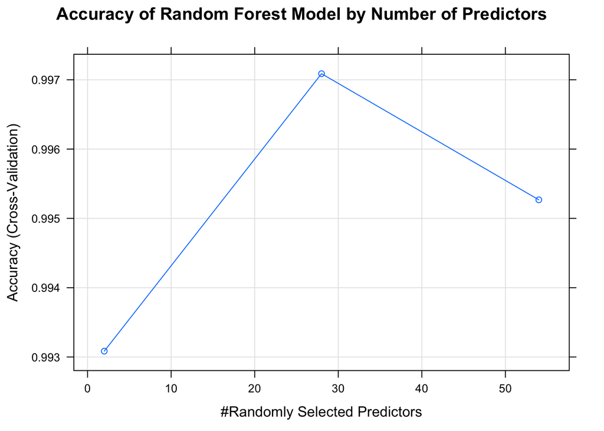

```r
plot(modelRF,main="Accuracy of Random Forest Model by Number of Predictors")
```

Overall Accuracy

```r
confidenceMatRF$overall
```

```
##       Accuracy          Kappa  AccuracyLower  AccuracyUpper   AccuracyNull
##      0.9971113      0.9963459      0.9953789      0.9983164      0.2844520
## AccuracyPValue  McnemarPValue
##      0.0000000            NaN
```

Using ranom forest with a crossvalidation in 5 steps we reach an overall model accuracy of 99.7%.

### Classification Trees

Here we use a classification tree.

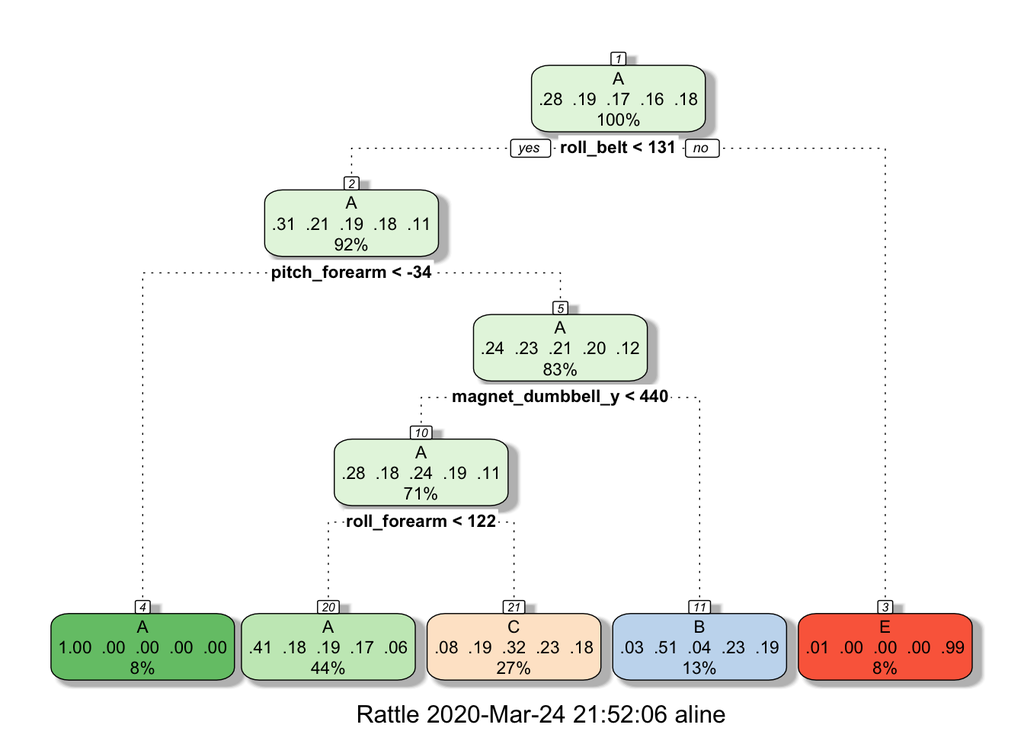

```r
modelCT <- train(classe~., data=Train, method="rpart",trControl=trControl)

#plot
fancyRpartPlot(modelCT$finalModel)
```

Now we apply it to the training data

```r
trainpredCT <- predict(modelCT, newdata = Test)

confidenceMatCT <- confusionMatrix(Test$classe, trainpredCT)

#display matrix
confidenceMatCT
```

```
## Confusion Matrix and Statistics
##
##           Reference
## Prediction    A    B    C    D    E
##          A 1516   26  127    0    5
##          B  485  390  264    0    0
##          C  461   36  529    0    0
##          D  428  159  377    0    0
##          E  163  149  285    0  485
##
## Overall Statistics
##
##                Accuracy : 0.4962
##                  95% CI : (0.4833, 0.509)
##     No Information Rate : 0.5188
##     P-Value [Acc > NIR] : 0.9998
##
##                   Kappa : 0.3416
##
##  Mcnemar's Test P-Value : NA
##
## Statistics by Class:
##
##                      Class: A Class: B Class: C Class: D Class: E
## Sensitivity            0.4966  0.51316  0.33439       NA  0.98980
## Specificity            0.9442  0.85385  0.88450   0.8362  0.88934
## Pos Pred Value         0.9056  0.34241  0.51559       NA  0.44824
## Neg Pred Value         0.6350  0.92204  0.78329       NA  0.99896
## Prevalence             0.5188  0.12914  0.26882   0.0000  0.08326
## Detection Rate         0.2576  0.06627  0.08989   0.0000  0.08241
## Detection Prevalence   0.2845  0.19354  0.17434   0.1638  0.18386
## Balanced Accuracy      0.7204  0.68351  0.60944       NA  0.93957
```

```r
#display model accuracy overall
confidenceMatCT$overall
```

```
##       Accuracy          Kappa  AccuracyLower  AccuracyUpper   AccuracyNull
##      0.4961767      0.3416344      0.4833222      0.5090351      0.5187766
## AccuracyPValue  McnemarPValue
##      0.9997508            NaN
```

### Gradient Boosting Method

First we build the control and model

```r
set.seed(132)
controlGBM <- trainControl(method = "repeatedcv", number = 5, repeats = 1)

modelGBM <- train(classe~., data = Train, method= "gbm", trControl=controlGBM, verbose=FALSE)

modelGBM$finalModel
```

```
## A gradient boosted model with multinomial loss function.
## 150 iterations were performed.
## There were 54 predictors of which 53 had non-zero influence.
```

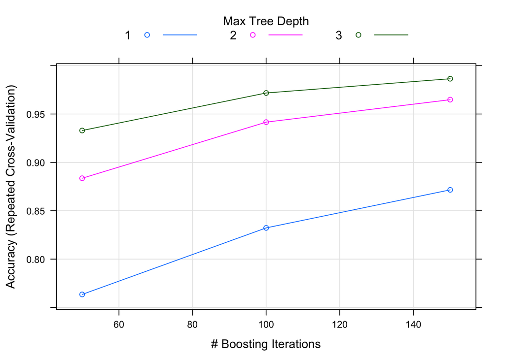

```r
#plot the model
plot(modelGBM)
```

Now we predict on Test dataset

```r
predictGBM <- predict(modelGBM, newdata=Test)
confidenceMatGBM <- confusionMatrix(predictGBM, Test$classe)
confidenceMatGBM
```

```
## Confusion Matrix and Statistics
##
##           Reference
## Prediction    A    B    C    D    E
##          A 1672   12    0    2    0
##          B    1 1118    9    4    3
##          C    0    7 1014   13    1
##          D    1    2    1  945    3
##          E    0    0    2    0 1075
##
## Overall Statistics
##
##                Accuracy : 0.9896
##                  95% CI : (0.9867, 0.9921)
##     No Information Rate : 0.2845
##     P-Value [Acc > NIR] : < 2.2e-16
##
##                   Kappa : 0.9869
##
##  Mcnemar's Test P-Value : NA
##
## Statistics by Class:
##
##                      Class: A Class: B Class: C Class: D Class: E
## Sensitivity            0.9988   0.9816   0.9883   0.9803   0.9935
## Specificity            0.9967   0.9964   0.9957   0.9986   0.9996
## Pos Pred Value         0.9917   0.9850   0.9797   0.9926   0.9981
## Neg Pred Value         0.9995   0.9956   0.9975   0.9961   0.9985
## Prevalence             0.2845   0.1935   0.1743   0.1638   0.1839
## Detection Rate         0.2841   0.1900   0.1723   0.1606   0.1827
## Detection Prevalence   0.2865   0.1929   0.1759   0.1618   0.1830
## Balanced Accuracy      0.9977   0.9890   0.9920   0.9894   0.9966
```

We look at the overall accuracy with 5 folds.

```r
confidenceMatGBM$overall[1]
```

```
##  Accuracy
## 0.9896347
```

Given that the random forest method yielded the highest accuracy it will be applied to the test data.

```r
PredictFinal <- predict(modelRF, newdata = TestDataClean)
PredictFinal
```

```
##  [1] B A B A A E D B A A B C B A E E A B B B
## Levels: A B C D E
```